# Avani -Technical Round for bank data

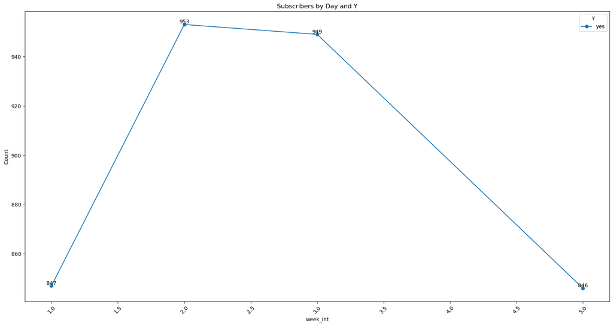

```python
# Grouping by 'day' and 'y' and calculating the size
day_analysis = data_subscribers.groupby(['week_int', 'y']).size()

# Convert the series to a DataFrame and reset the index
day_analysis = day_analysis.reset_index(name='count')

# Plotting
plt.figure(figsize=(20, 10))
for label, df in day_analysis.groupby('y'):
    plt.plot(df['week_int'], df['count'], marker='o', label=label)

# Annotate each point with its count value
for i, row in day_analysis.iterrows():
    plt.text(row['week_int'], row['count'], str(row['count']), ha='center', va='bottom')

plt.title('Subscribers by Day and Y')
plt.xlabel('week_int')
plt.ylabel('Count')
plt.xticks(rotation=45)
plt.legend(title='Y')
plt.show()
```

from the above graph, we can see the converstion rate of cx to take term plan is in the mid of the week. At these point we dont have data of weekends and my suggesstion is to start a temprary compaign on weekends increase the sale.

3) Campaign response rate

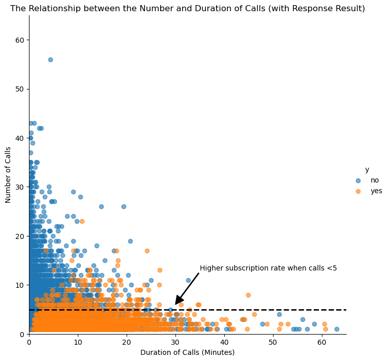

```python
dur_cam = sns.lmplot(x='duration', y='campaign',data = data_copy1,
                     hue = 'y',
                     fit_reg = False,
                     scatter_kws={'alpha':0.6}, height =7)

plt.axis([0,65,0,65])
plt.ylabel('Number of Calls')
plt.xlabel('Duration of Calls (Minutes)')
plt.title('The Relationship between the Number and Duration of Calls (with Response Result)')

# Annotation
plt.axhline(y=5, linewidth=2, color="k", linestyle='--')
plt.annotate('Higher subscription rate when calls <5',xytext = (35,13),
             arrowprops=dict(color = 'k', width=1),xy=(30,6))
plt.show()
```

In this scatter plot, clients subscribed to term deposits are denoted as "yes" while those did not are denoted as "no".

As we can see from the plot, “yes” clients and “no” clients are forming two relatively separate clusters. Compared to “no” clients”, “yes” clients were contacted by fewer times and had longer call duration. More importantly, after five campaign calls, clients are more likely to reject the term deposit unless the duration is high. Most “yes” clients were approached by less than 10 times.

This suggests that the bank should resist calling a client for more than five times, which can be disturbing and increase dissatisfaction.

#### Conclusion

According to previous analysis, a target customer profile can be established. The most responsive customers possess these features:

- Feature 1: age < 30 or age > 60
- Feature 2: Education: more educated customer are likely incline to take term plan
- Feature 3: Job: Cx with admin and blue collar job are majority in taking term plan.

  On the one hand, it will increase the efficiency of the bank’s telemarketing campaign, saving time and efforts. On the other hand, it prevents some clients from receiving undesirable advertisements, raising customer satisfaction. With the aid of logistic and ridge regression models, the bank can enter a virtuous cycle of effective marketing, more investments and happier customers.

#### Recommendation

- Optimal Timing When planning a marketing strategy, it’s crucial to consider external factors like the timing of calls. Analysis shows that March, September, October, and December have the highest success rates. However, more data is needed to confirm if this trend is consistent. If it is, the bank should focus its telemarketing efforts during these months, particularly in the fall and spring.
- Enhanced Marketing Design Targeting the right customers will lead to more positive responses, helping to correct the imbalance in the original dataset and provide the bank with more accurate data. To boost subscription rates, the bank should also review and improve its campaign content and design to make it more attractive to its target audience.
- Improved Service Delivery Understanding customer demographics, such as marital status, occupation, and loan status, allows the bank to tailor its services better. This information helps predict when customers might need specific financial services, enabling the bank to meet their needs more effectively and provide the right services at the right time.